# HT01

Sara, Cristian, Guillermo

2023-02-02

```r
movies <- read.csv("movies.csv")
```

## Cristian

### 1. Haga una exploración rápida de sus datos, para eso haga un resumen de su conjunto de datos.

```r
summary(movies)
```

```
##        id             budget             genres            homePage
##  Min.   :     5   Min.   :        0   Length:10000       Length:10000
##  1st Qu.: 12286   1st Qu.:        0   Class :character   Class :character
##  Median :152558   Median :   500000   Mode  :character   Mode  :character
##  Mean   :249877   Mean   : 18551632
##  3rd Qu.:452022   3rd Qu.: 20000000
##  Max.   :922260   Max.   :380000000
##  productionCompany  productionCompanyCountry productionCountry
##  Length:10000       Length:10000             Length:10000
##  Class :character   Class :character         Class :character
##  Mode  :character   Mode  :character         Mode  :character
##
##
##
##     revenue             runtime        video           director
##  Min.   :0.000e+00   Min.   :  0.0   Mode :logical   Length:10000
##  1st Qu.:0.000e+00   1st Qu.: 90.0   FALSE:9430      Class :character
##  Median :1.631e+05   Median :100.0   TRUE :84        Mode  :character
##  Mean   :5.674e+07   Mean   :100.3   NA's :486
##  3rd Qu.:4.480e+07   3rd Qu.:113.0
##  Max.   :2.847e+09   Max.   :750.0
##     actors          actorsPopularity   actorsCharacter    originalTitle
##  Length:10000       Length:10000       Length:10000       Length:10000
##  Class :character   Class :character   Class :character   Class :character
##  Mode  :character   Mode  :character   Mode  :character   Mode  :character
##
##
##
##     title           originalLanguage     popularity        releaseDate
##  Length:10000       Length:10000       Min.   :    4.258   Length:10000
##  Class :character   Class :character   1st Qu.:   14.578   Class :character
##  Mode  :character   Mode  :character   Median :   21.906   Mode  :character
##                                        Mean   :   51.394
##                                        3rd Qu.:   40.654
##                                        Max.   :11474.647
##     voteAvg         voteCount      genresAmount    productionCoAmount
##  Min.   : 1.300   Min.   :    1   Min.   : 0.000   Min.   : 0.000
##  1st Qu.: 5.900   1st Qu.:  120   1st Qu.: 2.000   1st Qu.: 2.000
##  Median : 6.500   Median :  415   Median : 3.000   Median : 3.000
##  Mean   : 6.483   Mean   : 1342   Mean   : 2.596   Mean   : 3.171
##  3rd Qu.: 7.200   3rd Qu.: 1316   3rd Qu.: 3.000   3rd Qu.: 4.000
##  Max.   :10.000   Max.   :30788   Max.   :16.000   Max.   :89.000
##  productionCountriesAmount  actorsAmount    castWomenAmount
##  Min.   :  0.000           Min.   :     0   Length:10000
##  1st Qu.:  1.000           1st Qu.:    13   Class :character
##  Median :  1.000           Median :    21   Mode  :character
##  Mean   :  1.751           Mean   :  2148
##  3rd Qu.:  2.000           3rd Qu.:    36
##  Max.   :155.000           Max.   :919590
##  castMenAmount
##  Length:10000
##  Class :character
##  Mode  :character
##
##
##
```

## Sara

### 2. Diga el tipo de cada una de las variables (cualitativa ordinal o nominal, cuantitativa continua, cuantitativa discreta)

```r
str(movies)
```

```
## 'data.frame':    10000 obs. of  27 variables:
##  $ id                       : int  5 6 11 12 13 14 15 16 18 19 ...
##  $ budget                   : int  4000000 21000000 11000000 94000000 55000000 15000000 839727 12800000 90000000 1300000 ...
##  $ genres                   : chr  "Crime|Comedy" "Action|Thriller|Crime" "Adventure|Action|Science Fiction" "Animation|Family" ...
##  $ homePage                 : chr  "https://www.miramax.com/movie/four-rooms/" NA "http://www.starwars.com/films/star-wars-episode-iv-a-new-hope" "http://movies.disney.com/finding-nemo" ...
##  $ productionCompany        : chr  "Miramax|A Band Apart" "Universal Pictures|Largo Entertainment|JVC" "Lucasfilm|20th Century Fox" "Pixar" ...
##  $ productionCompanyCountry : chr  "US|US" "US|US|JP" "US|US" "US" ...
##  $ productionCountry        : chr  "United States of America" "Japan|United States of America" "United States of America" "United States of America" ...
##  $ revenue                  : num  4.26e+06 1.21e+07 7.75e+08 9.40e+08 6.77e+08 ...
##  $ runtime                  : int  98 110 121 100 142 122 119 141 126 149 ...
##  $ video                    : logi  FALSE FALSE NA NA FALSE FALSE ...
##  $ director                 : chr  "Allison Anders|Alexandre Rockwell|Robert Rodriguez|Quentin Tarantino" "Stephen Hopkins" "George Lucas" "Andrew Stanton" ...
##  $ actors                   : chr  "Tim Roth|Jennifer Beals|Antonio Banderas|Valeria Golino|David Proval|Sammi Davis|Amanda de Cadenet|Madonna|Ione Skye|Lili Taylo "Emilio Estevez|Cuba Gooding Jr.|Denis Leary|Stephen Dorff|Jeremy Piven|Peter Greene|Michael DeLorenzo|Everlast|Michael Wiseman| "FAL…
##  $ actorsPopularity         : chr  "22.225|23.519|17.816|19.893|9.027|7.147|7.769|6.476|7.906|12.838|17.988|20.027|4.47|0.6|1.286|23.95|22.082|3.44"| __truncated__ "9.008|6.383|10.757|18.295|11.772|14.777|9.669|0.98|4.369|0.6|1.38|2.835|3.807|1.4|1.111" "11.881|24.542|14.434|10.651|6.888|5.811|1.…
##  $ actorsCharacter          : chr  "Ted the Bellhop|Angela|Man|Athena|Siegfried|Jezebel|Diana|Elspeth|Eva|Raven|Kiva|Wife|Sarah|Juancho|Corpse|TV Dancing Girl|Ches "Frank Wyatt|Mike Peterson|Fallon|John Wyatt|Ray Cochran|Sykes|Teddy, the Kid|Rhodes|Travis|Dre|Buck|Linda Wyatt|Clarissa|Rita|C "Luk…
##  $ originalTitle            : chr  "Four Rooms" "Judgment Night" "Star Wars" "Finding Nemo" ...
##  $ title                    : chr  "Four Rooms" "Judgment Night" "Star Wars" "Finding Nemo" ...
##  $ originalLanguage         : chr  "en" "en" "en" "en" ...
##  $ popularity               : num  20.9 9.6 100 134.4 58.8 ...
##  $ releaseDate              : chr  "1995-12-09" "1993-10-15" "1977-05-25" "2003-05-30" ...
##  $ voteAvg                  : num  5.7 6.5 8.2 7.8 8.5 8 8 7.9 7.5 8.2 ...
##  $ voteCount                : int  2077 223 16598 15928 22045 9951 4253 1335 8726 1963 ...
##  $ genresAmount             : int  2 3 3 2 3 1 2 2 5 2 ...
##  $ productionCoAmount       : int  2 3 2 1 2 2 2 26 2 1 ...
##  $ productionCountriesAmount: int  1 2 1 1 1 1 1 12 1 1 ...
##  $ actorsAmount             : int  25 15 105 24 76 40 152 29 117 24 ...
##  $ castWomenAmount          : chr  "15" "3" "5" "5" ...
##  $ castMenAmount            : chr  "9" "9" "62" "18" ...
```

### Tipo de las variables

- id: cualitativa ordinal
- popularity: cuantitativa continua
- budget: cuantitativa discreta
- revenue: cuantitativa discreta
- original_title: cualitativa nominal
- originalLanguage: cualitativa nominal
- title: cualitativa nominal
- homePage: cualitativa nominal
- video: cualitativa nominal
- director: cualitativa nominal
- runtime: cuantitativa discreta
- genres: cualitativa nominal
- genresAmount: cuantitativa discreta
- productionCompany: cualitativa nominal
- productionCoAmount: cuantitativa discreta
- productionCompantCountry: cualitativa nominal
- productionCountry: cualitativa nominal
- productionCountriesAmount: cuantitativa discreta
- releaseDate: cualitativa nominal
- voteCount: cuantitativa discreta
- voteAvg: cuantitativa continua
- actors: cualitativa nominal
- actorsPopularity: cuantitativa continua
- actorsCharacter: cualitativa nominal
- actorsAmount: cuantitativa discreta
- castWomenAmount: cuantitativa discreta
- castMenAmount: cuantitativa discreta

### 3. Investigue si las variables cuantitativas siguen una distribución normal y haga una tabla de frecuencias de las variables cualitativas. Explique todos los resultados.

### popularity

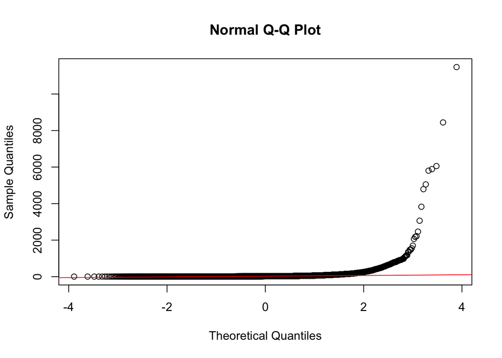

```r
library(nortest)
qqnorm(movies$popularity)
qqline(movies$popularity, col="red")
```

```r
normP <- lillie.test(movies$popularity)
pnormP <- normP$p.value
```

norm: 0

### budget

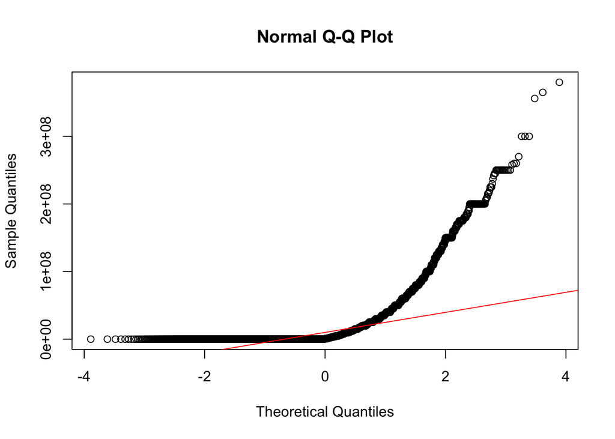

```r
library(nortest)
qqnorm(movies$budget)
qqline(movies$budget, col="red")
```

```r
normBud <- lillie.test(movies$budget)
pnormBud <- normBud$p.value
```

norm: 0

### revenue

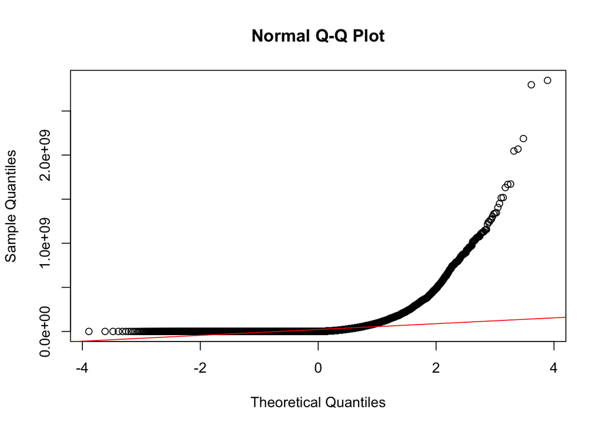

```r
library(nortest)
qqnorm(movies$revenue)
qqline(movies$revenue, col="red")
```

```r
normRev <- lillie.test(movies$revenue)
pnormRev <- normRev$p.value
```

norm: 0

### runtime

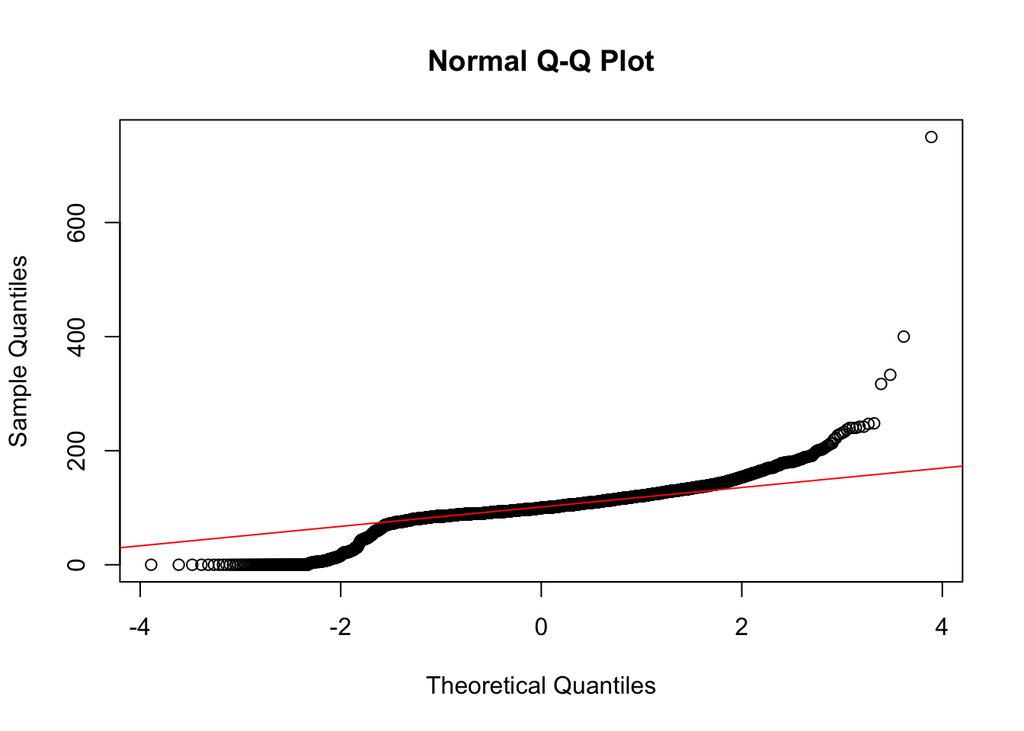

```r
library(nortest)
qqnorm(movies$runtime)
qqline(movies$runtime, col="red")
```

```r
normRun <- lillie.test(movies$runtime)
pnormRun <- normRun$p.value
```

norm: 0

### genresAmount

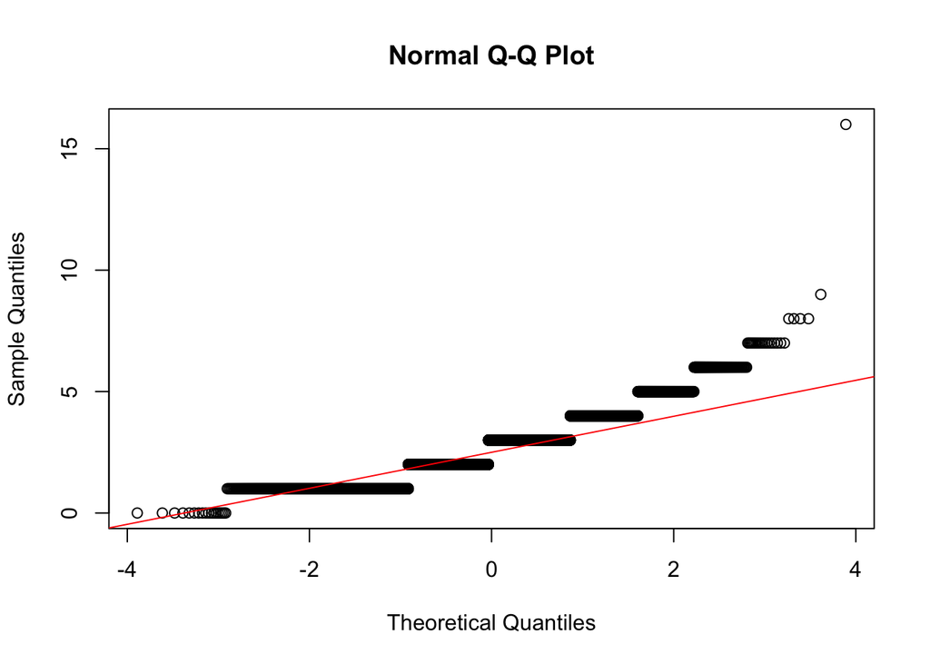

```r
library(nortest)
qqnorm(movies$genresAmount)
qqline(movies$genresAmount, col="red")
```

```r
normGenAm <- lillie.test(movies$genresAmount)
pnormGenAm <- normGenAm$p.value
```

norm: 0

### original_title

```r
#table(movies$originalTitle)
```

### 4.1 ¿Cuáles son las 10 películas que contaron con más presupuesto?

```r
library(dplyr)
moviesP <- movies[order(-movies$budget),]
head(select(moviesP, title, budget), 10)
```

```
##                                            title    budget
## 717  Pirates of the Caribbean: On Stranger Tides 380000000
## 4711                     Avengers: Age of Ultron 365000000
## 5953                           Avengers: Endgame 356000000
## 164     Pirates of the Caribbean: At World's End 300000000
## 4954                              Justice League 300000000
## 5954                      Avengers: Infinity War 300000000
## 608                             Superman Returns 270000000
## 3792                                     Tangled 260000000
## 7135                               The Lion King 260000000
## 281                                 Spider-Man 3 258000000
```

### 4.2 ¿Cuáles son las 10 películas que más ingresos tuvieron?

```r
library(dplyr)
moviesP <- movies[order(-movies$revenue),]
head(select(moviesP, title, revenue), 10)
```

```
##                             title    revenue
## 3211                       Avatar 2847246203
## 5953            Avengers: Endgame 2797800564
## 308                       Titanic 2187463944
## 4948 Star Wars: The Force Awakens 2068223624
## 5954       Avengers: Infinity War 2046239637
## 4915               Jurassic World 1671713208
## 7135                The Lion King 1667635327
## 9050      Spider-Man: No Way Home 1631853496
## 3398                 The Avengers 1518815515
## 5088                    Furious 7 1515047671
```

### 4.3 ¿Cuál es la película que más votos tuvo?

```r
library(dplyr)
moviesP <- movies[order(-movies$voteCount),]
head(select(moviesP, title, voteCount), 1)
```

```
##          title voteCount
## 3512 Inception     30788
```

### 4.4 ¿Cuál es la peor película de acuerdo a los votos de todos los usuarios?

```r
min_votes <- min(movies$voteAvg)
movie <- movies[movies$voteAvg == min_votes,"title"]
```

### 4.5 ¿Cuántas películas se hicieron en cada año? ¿En qué año se hicieron más películas? Haga un gráfico de barras

```r
dates <- as.POSIXct(movies[,"releaseDate"], format = "%Y-%m-%d")
years <- sort(c(format(dates, format="%Y")))
release_years = sort(table(years), decreasing = TRUE)
print(summary.factor(factor(years)))
```

```
## 1902 1920 1921 1922 1925 1926 1927 1929 1930 1931 1932 1933 1935 1936 1937 1938
##    1    1    1    1    2    1    2    1    1    4    1    1    1    1    1    1
## 1939 1940 1941 1942 1943 1944 1946 1947 1948 1949 1950 1951 1952 1953 1954 1955
##    4    7    4    4    2    4    4    4    7    3    4    6    8   13   11    7
## 1956 1957 1958 1959 1960 1961 1962 1963 1964 1965 1966 1967 1968 1969 1970 1971
##   11   15    9   12    9   10   13   16   10    8   13   16   15   11   12   16
## 1972 1973 1974 1975 1976 1977 1978 1979 1980 1981 1982 1983 1984 1985 1986 1987
##   13   19   16   16   18   21   22   20   20   30   35   28   41   47   48   53
## 1988 1989 1990 1991 1992 1993 1994 1995 1996 1997 1998 1999 2000 2001 2002 2003
##   59   59   47   50   63   83   65   79   76   84   92   97  132  176  185  199
## 2004 2005 2006 2007 2008 2009 2010 2011 2012 2013 2014 2015 2016 2017 2018 2019
##  229  245  272  266  282  342  307  361  328  412  432  450  557  618  629  612
## 2020 2021 2022
##  533  816    7
```

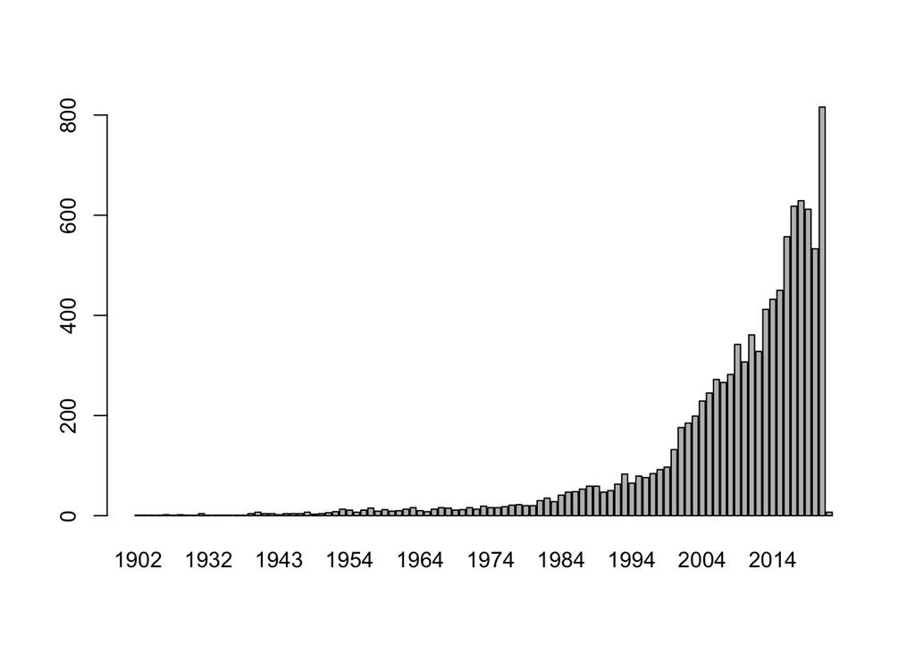

```r
barplot(table(years))
```

El año con más peliculas estrenadas fue 2021.

### 4.6 ¿Cuál es el género principal de las 20 películas más recientes? ¿Cuál es el género principal que predomina en el conjunto de datos? Represéntelo usando un gráfico

```r
recent_20_movies_genres = head(movies[order(movies$releaseDate, decreasing = TRUE),"genres"],20)
genres_factor <- factor()
for (g in recent_20_movies_genres){
  splitted = unlist(strsplit(g, "|", fixed=T))
  new_factor <- factor(splitted)
  genres_factor <- append(genres_factor, new_factor)
}
f <- unlist(genres_factor)
print(summary.factor(f))
```

```
##       Drama      Comedy     Mystery      Action       Crime    Thriller
##           7           7           2           3           1           3
## Documentary     Romance   Adventure   Animation      Family     Fantasy
##           1           3           2           1           1           3
##      Horror
##           2
```

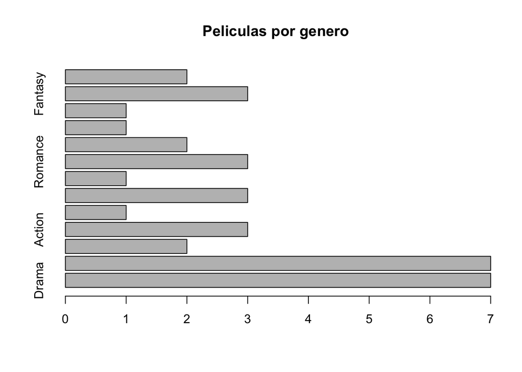

```r
barplot(table(f), horiz = T, main="Peliculas por genero")
```

El genero principal de las 20 peliculas más recientes es drama y comedia.

```r
movies_genres = movies[,"genres"]
genres_factor <- factor()
genres_c <- c()

for (g in movies_genres){
  splitted = unlist(strsplit(g, "|", fixed=T))
  genres_c <- append(genres_c, unlist(strsplit(g, "|", fixed=T))[1])

  new_factor <- factor(splitted)
  genres_factor <- append(genres_factor, new_factor)
}
movies$mainGenre <- genres_c
f <- unlist(genres_factor)
print(summary.factor(f))
```

```
##          Comedy           Crime          Action        Thriller       Adventure
##            3018            1225            2632            2565            1769
## Science Fiction       Animation          Family           Drama         Romance
##            1267            1460            1407            3789            1428
##         Mystery         Fantasy             War           Music         Western
##             804            1284             275             315             120
##         History          Horror        TV Movie     Documentary
##             406            1512             276             299
```

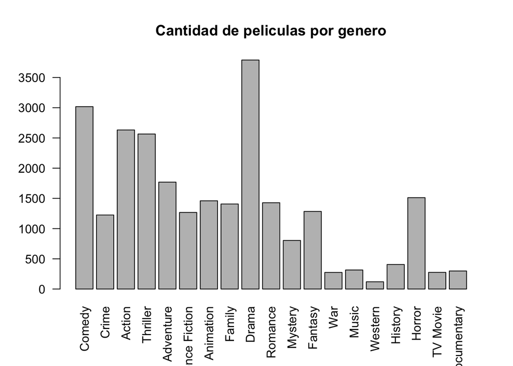

```r
barplot(table(f), las=2, main="Cantidad de peliculas por genero")
```

### 4.7 ¿Las películas de qué genero principal obtuvieron mayores ganancias?

```r
distinct_genres <- unique(movies[,"mainGenre"])
ag <- aggregate(movies$revenue, by=list(Genre=movies$mainGenre), FUN=sum)
names(ag)[names(ag) == 'x'] <- 'revenue'
print(summary(ag))
```

```
##     Genre              revenue
##  Length:19          Min.   :0.000e+00
##  Class :character   1st Qu.:4.067e+09
##  Mode  :character   Median :1.711e+10
##                     Mean   :2.984e+10
##                     3rd Qu.:3.563e+10
##                     Max.   :1.409e+11
```

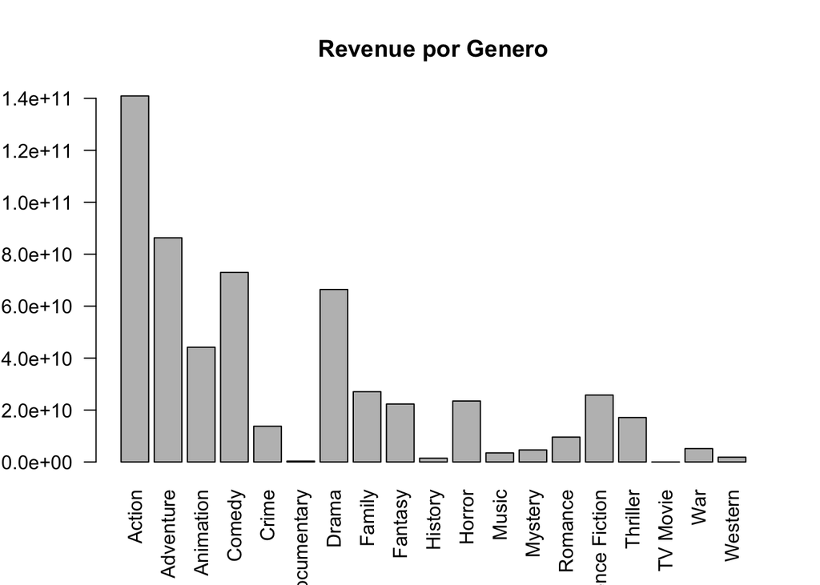

```r
vector <- ag$revenue
names(vector)<-ag$Genre
barplot(vector, las=2, main="Revenue por Genero")
```

Las peliculas de acción han tenido mayores ganancias.

películas con más actores en los últimos años?

```r
actor_q = movies[, "actorsAmount"]
revenue = movies[, "revenue"]
q = cor(actor_q, revenue, method="spearman")
print(q)
```

```
## [1] 0.5561046
```

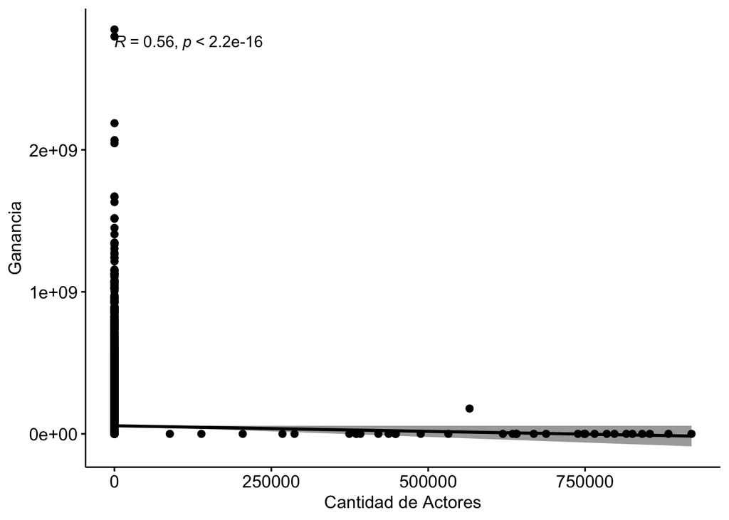

```r
library("ggpubr")
ggscatter(movies, x = "actorsAmount", y = "revenue",
          add = "reg.line", conf.int = TRUE,
          cor.coef = TRUE, cor.method = "spearman",
          xlab = "Cantidad de Actores", ylab = "Ganancia")
```

popularidad y los ingresos de las películas?

[figure not shown]

```r
#actor_w = movies[, "castWomenAmount"]
#actor_m = movies[, "castMenAmount"]

#revenue = movies[, "revenue"]
#popularity = movies[, "popularity"]

library("ggpubr")
ggscatter(movies, x = "castWomenAmount", y = "popularity",
          add = "reg.line", conf.int = TRUE,
          cor.coef = TRUE, cor.method = "pearson",
          xlab = "Cantidad de Mujeres", ylab = "Ganancia")
```

### 4.10 ¿Quiénes son los directores que hicieron las 20 películas mejor calificadas?

```r
order_best_movies <- movies[order(-movies$voteCount),]
result <- order_best_movies[1:20, c("title", "director")]
print(result)
```

```
##                                                  title
## 3512                                         Inception
## 5028                                      Interstellar
## 88                                     The Dark Knight
## 3398                                      The Avengers
## 5890                                          Deadpool
## 3211                                            Avatar
## 4826                           Guardians of the Galaxy
## 5954                            Avengers: Infinity War
## 276                                         Fight Club
## 375                                       Pulp Fiction
## 696                                           Iron Man
## 5                                         Forrest Gump
## 368           Harry Potter and the Philosopher's Stone
## 4338                                  Django Unchained
```

[output cut: 27 more lines]

### 4.11 ¿Cómo se correlacionan los presupuestos con los ingresos? ¿Los altos presupuestos significan altos ingresos? Haga los gráficos que necesite, histograma, diagrama de dispersión

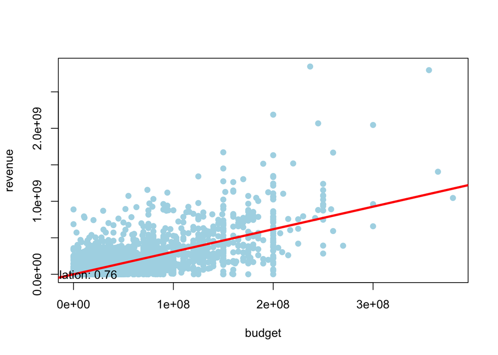

```r
budget  <- movies$budget
revenue  <- movies$revenue
plot(budget, revenue, pch = 19, col = "lightblue")
abline(lm(revenue ~ budget), col = "red", lwd = 3)
text(paste("Correlation:", round(cor(budget, revenue), 2)), x = 25, y = 95)
```

### 4.15 ¿A qué género principal pertenecen las películas más largas?

```r
long_movies <- movies[order(-movies$runtime), ]
result_five_movies <- long_movies[0:5, ]

for (i in 0:5) {
  cat(result_five_movies$title[i], ":", result_five_movies$genres[i], "\n")
}
```

```
##  :
## How Ponyo was Born ~Hayao Miyazaki's Thought Process~ : Documentary
## Crystal Lake Memories: The Complete History of Friday the 13th : Documentary
## Napoleon : Drama|History|War
## 1900 : Drama|History
## Cleopatra : Drama|History|Romance
```